# Revenue_Analytics

## Import packages used in the ananlysis

```python
import pandas as pd
import numpy as np
import matplotlib.pyplot as plt
from sklearn.linear_model import LinearRegression
import statsmodels.api as sm
from sklearn.preprocessing import PolynomialFeatures
from statsmodels.stats.anova import anova_lm
from sklearn.metrics import mean_squared_error
from scipy.optimize import minimize_scalar
```

## Load csv file named online_retail2 and determine the variables, counts, and data types.

### This example file does not contain cost data, but can at least be used to demonstrate revenue calculations.

### The file was downloaded from resource materials for a Udemy course on revenue analytics, and is based on a popular training dataset - UK Online Retail file donated to the UC Irvine Machine Learning Respository. https://archive.ics.uci.edu/dataset/352/online+retail

```python
#Provide path where dataset is stored on my computer
online_retail = pd.read_csv(r'C:\Users\Shane\OneDrive\Desktop\Python Projects\online_retail2.csv')

#Info() shows the variable names (columns), counts (of non-null values) and data types
online_retail.info()
```

```
<class 'pandas.core.frame.DataFrame'>
RangeIndex: 1067371 entries, 0 to 1067370
Data columns (total 8 columns):
 #   Column       Non-Null Count    Dtype
---  ------       --------------    -----
 0   Invoice      1067371 non-null  object
 1   StockCode    1067371 non-null  object
 2   Description  1062989 non-null  object
 3   Quantity     1067371 non-null  int64
 4   InvoiceDate  1067371 non-null  object
 5   Price        1067371 non-null  float64
 6   Customer ID  824364 non-null   float64
 7   Country      1067371 non-null  object
dtypes: float64(2), int64(1), object(5)
memory usage: 65.1+ MB
```

## Determine the breakdown of Country to see which countries are most represented, displaying it as a % of total

```python
#Value counts provides the raw count of each country in the dataset. Normalize makes the value a proportion. Rounding to the 4th decimal place and multiplying by 100 shows % of total
online_retail['Country'].value_counts(normalize=True).round(4) * 100
```

```
Country
United Kingdom          91.94
EIRE                     1.67
Germany                  1.65
France                   1.34
Netherlands              0.48
Spain                    0.36
Switzerland              0.30
Belgium                  0.29
Portugal                 0.25
Australia                0.18
Channel Islands          0.16
Italy                    0.14
Norway                   0.14
Sweden                   0.13
Cyprus                   0.11
Finland                  0.10
Austria                  0.09
Denmark                  0.08
Unspecified              0.07
Greece                   0.06
Japan                    0.05
Poland                   0.05
USA                      0.05
United Arab Emirates     0.05
Israel                   0.03
Hong Kong                0.03
Singapore                0.03
Malta                    0.03
Iceland                  0.02
Canada                   0.02
Lithuania                0.02
RSA                      0.02
Bahrain                  0.01
Brazil                   0.01
Thailand                 0.01
Korea                    0.01
European Community       0.01
Lebanon                  0.01
West Indies              0.01
Bermuda                  0.00
Nigeria                  0.00
Czech Republic           0.00
Saudi Arabia             0.00
Name: proportion, dtype: float64
```

## Since UK is over 90% of the data, I will be focusing on just records coming from there by creating a new dataframe. I complete a similar calculation to above to show that UK is now 100% of the new dataframe

```python
#Filters for records where country = United Kingdom
uk_retail_full = online_retail[online_retail['Country'] == 'United Kingdom']

uk_retail_full['Country'].value_counts(normalize=True).round(2) * 100
```

```
Country
United Kingdom    100.0
Name: proportion, dtype: float64
```

## Use info to determine if there are still records with missing values for any of the variables. We see that description and customer ID have missing values. I then updated the uk_retail dataframe further to only include purchases that contain a valid customer ID

```python
uk_retail_full.info()

#Removes records from the dataset where Customer ID is blank (note in a real world scenario, it would be important to understand why there are blanks here, which would require further digging / understanding of the data nuances
uk_retail = uk_retail_full.dropna(subset=['Customer ID']).reset_index()
```

```
<class 'pandas.core.frame.DataFrame'>
Index: 981330 entries, 0 to 1067354
Data columns (total 8 columns):
 #   Column       Non-Null Count   Dtype
---  ------       --------------   -----
 0   Invoice      981330 non-null  object
 1   StockCode    981330 non-null  object
 2   Description  976948 non-null  object
 3   Quantity     981330 non-null  int64
 4   InvoiceDate  981330 non-null  object
 5   Price        981330 non-null  float64
 6   Customer ID  741301 non-null  float64
 7   Country      981330 non-null  object
dtypes: float64(2), int64(1), object(5)
memory usage: 67.4+ MB
```

### Running info again shows that removing these records without a customer ID also solves the discrepancy with Description having missing values

```python
uk_retail.info()
```

```
<class 'pandas.core.frame.DataFrame'>
RangeIndex: 741301 entries, 0 to 741300
Data columns (total 9 columns):
 #   Column       Non-Null Count   Dtype
---  ------       --------------   -----
 0   index        741301 non-null  int64
 1   Invoice      741301 non-null  object
 2   StockCode    741301 non-null  object
 3   Description  741301 non-null  object
 4   Quantity     741301 non-null  int64
 5   InvoiceDate  741301 non-null  object
 6   Price        741301 non-null  float64
 7   Customer ID  741301 non-null  float64
 8   Country      741301 non-null  object
dtypes: float64(2), int64(2), object(5)
memory usage: 50.9+ MB
```

## Now I will see which products are most popular, and provide their product description using a groupby and size function. I sort by number of times each stock code appears in this updated dataframe. Since this value represents the number of times a product appears as a record, and not the quantity of products sold, it is stored as count.

```python
UK_stock_counts = (
    uk_retail.groupby(['StockCode', 'Description'])
    .size()
    .reset_index(name='Count')
    .sort_values(by='Count', ascending=False)
)

#To reduce noise, I'm only looking at the top 5 product counts
UK_stock_counts.head(5)
```

|  | StockCode | Description | Count |
| --- | --- | --- | --- |
| 4732 | 85123A | WHITE HANGING HEART T-LIGHT HOLDER | 5120 |
| 1855 | 22423 | REGENCY CAKESTAND 3 TIER | 3246 |
| 4438 | 84879 | ASSORTED COLOUR BIRD ORNAMENT | 2646 |
| 4706 | 85099B | JUMBO BAG RED RETROSPOT | 2547 |
| 504 | 21034 | REX CASH+CARRY JUMBO SHOPPER | 2136 |

## I will now dig further into the product 85123A, to see how many records are purchases and how many are returns, and the total revenue generated / returned by this product

```python
top_item = uk_retail[uk_retail['StockCode'] == '85123A']

# Separate purchases (quantity over 0) and returns (quantity under 0)
purchases = top_item[top_item['Quantity'] > 0]
returns = top_item[top_item['Quantity'] < 0]

# Count of purchases and returns
num_purchases = len(purchases)
num_returns = len(returns)
final_units_sold = num_purchases - num_returns

# Total cost (assuming returns are negative amounts)
total_revenue = (purchases['Quantity'] * purchases['Price']).sum()
total_returns = (returns['Quantity'] * returns['Price']).sum()


#Profit here represents revenue - returns (since returns is already a negative value, we are adding instead of subtracting
profit = total_revenue + total_returns

# Print results
print(f"Purchases: {num_purchases:,} - £{total_revenue:,.2f}")
print(f"Purchases: {num_returns:,} - £{total_returns:,.2f}")
print(f"Profit: {final_units_sold:,} - £{total_revenue:,.2f}")
```

```
Purchases: 4,997 - £232,984.06
Purchases: 130 - £-9,193.00
Profit: 4,867 - £232,984.06
```

## Now I will dig further into the optimal pricing of the product given the amounts purchased at listed prices. First I will vizualize this demand

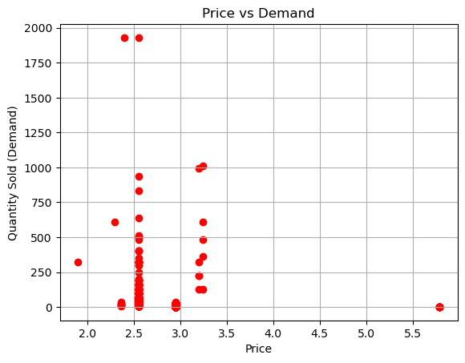

```python
plt.scatter(purchases['Price'], purchases['Quantity'], color='red')
plt.xlabel('Price')
plt.ylabel('Quantity Sold (Demand)')
plt.title('Price vs Demand')
plt.grid(True)
plt.show()
```

## This product is most typically sold for somewhere around £2.5. Purchashes range from small (100 or less) to large (~2k). I see there is at least one record that appears to be an outlier, where there was a purchase where the price was nearly 2x the average. I will remove this outlier and try to find a line of best fit.

## It is visually apparent that a linear line is not going to be the best fit, but I am starting there as part of this practice

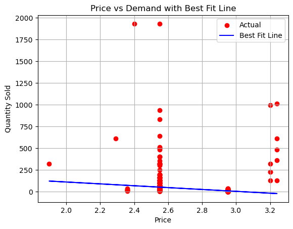

```python
purchases = purchases[purchases['Price'] < 4]

# Extract key metrics (price as independent variable, quantity as dependent)
X = purchases[['Price']]
y = purchases['Quantity']

# Fit linear model
linear_model = LinearRegression()
linear_model.fit(X, y)

# Predict values
purchases['predicted_quantity'] = linear_model.predict(X)

# Plot with line
plt.scatter(purchases['Price'], purchases['Quantity'], label='Actual', color='red')
plt.plot(purchases['Price'], purchases['predicted_quantity'], label='Best Fit Line', color='blue')
plt.xlabel('Price')
plt.ylabel('Quantity Sold')
plt.title('Price vs Demand with Best Fit Line')
plt.legend()
plt.grid(True)
plt.show()
```

## Use built-in commands to determine and display the best fit linear demand function

```python
slope = linear_model.coef_[0]
intercept = linear_model.intercept_
print(f"Demand = {intercept:.2f} + ({slope:.2f}) * Price")
```

```
Demand = 324.90 + (-107.33) * Price
```

## Use this demand function to determine the optimal price for max revenue, corresponding demand, and the max revenue possible given that demand

```python
# Demand function: Demand = 324.90 - 107.33 * Price

# Define revenue function
def revenue(price):
    return price * (intercept - (slope * price))

# Find the optimal price for maximum revenue
# Since this is a quadratic function, the max occurs at the vertex
a = slope
b = intercept
optimal_price = -b / (2 * a)

# Calculate max revenue and corresponding demand
max_revenue = revenue(optimal_price)
optimal_demand = intercept - (slope * optimal_price)

print(f"Optimal Price for Max Revenue: ${optimal_price:.2f}")
print(f"Corresponding Demand: {optimal_demand:.0f} units")
print(f"Maximum Revenue: ${max_revenue:,.2f}")
```

```
Optimal Price for Max Revenue: $1.51
Corresponding Demand: 487 units
Maximum Revenue: $737.62
```

## Use statsmodel package to show the Ordinary Least Squares Regression results. Realistically, this step would be completed before calculating optimal price and max revenue, because we can confirm based on metrics such as the r-squared that the linear model is a very poor fit.

```python
X_sm = sm.add_constant(purchases['Price'])  # adds intercept
linear_sm = sm.OLS(purchases['Quantity'], X_sm).fit()
print(linear_sm.summary())
```

```
                            OLS Regression Results
==============================================================================
Dep. Variable:               Quantity   R-squared:                       0.093
Model:                            OLS   Adj. R-squared:                  0.093
Method:                 Least Squares   F-statistic:                     511.4
Date:                Fri, 27 Jun 2025   Prob (F-statistic):          7.12e-108
Time:                        16:40:00   Log-Likelihood:                -27099.
No. Observations:                4988   AIC:                         5.420e+04
Df Residuals:                    4986   BIC:                         5.422e+04
Df Model:                           1
Covariance Type:            nonrobust
==============================================================================
                 coef    std err          t      P>|t|      [0.025      0.975]
------------------------------------------------------------------------------
const        324.9012     13.624     23.848      0.000     298.192     351.610
Price       -107.3321      4.746    -22.614      0.000    -116.637     -98.027
==============================================================================
Omnibus:                    11285.129   Durbin-Watson:                   1.915
Prob(Omnibus):                  0.000   Jarque-Bera (JB):         76086702.848
Skew:                          21.324   Prob(JB):                         0.00
Kurtosis:                     606.553   Cond. No.                         55.9
==============================================================================

Notes:
[1] Standard Errors assume that the covariance matrix of the errors is correctly specified.
```

## Try a quadratic model to see if the fit will be any better

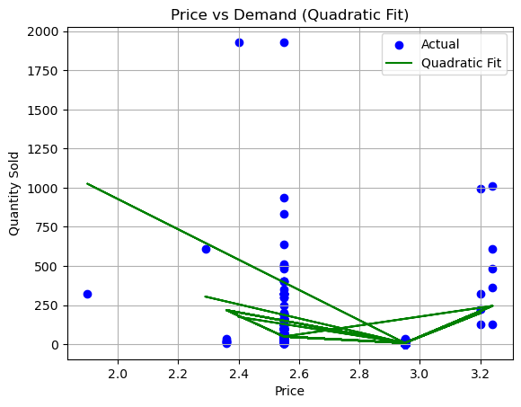

```
Demand ≈ 10337.44 + (-7433.83)*Price + (1332.96)*Price²
```

```python
poly = PolynomialFeatures(degree=2)
X_poly = poly.fit_transform(purchases[['Price']])
model_poly = LinearRegression()
model_poly.fit(X_poly, y)

# Predict and plot
purchases['predicted_quantity_poly'] = model_poly.predict(X_poly)

plt.scatter(purchases['Price'], purchases['Quantity'], label='Actual', color='blue')
plt.plot(purchases['Price'], purchases['predicted_quantity_poly'], label='Quadratic Fit', color='green')
plt.xlabel('Price')
plt.ylabel('Quantity Sold')
plt.title('Price vs Demand (Quadratic Fit)')
plt.legend()
plt.grid(True)
plt.show()

# Print equation
a, b, c = model_poly.coef_
intercept = model_poly.intercept_
print(f"Demand ≈ {intercept:.2f} + ({b:.2f})*Price + ({c:.2f})*Price²")
```

## R2 shows an improvement, but this would still be too low to utilize

```python
purchases['Price_sq'] = purchases['Price'] ** 2

# Define independent variables (X) and dependent variable (y)
Xs = purchases[['Price', 'Price_sq']]
Xs = sm.add_constant(Xs)  # Adds the intercept term
y = purchases['Quantity']

# Fit OLS regression
quadratic_sm = sm.OLS(y, Xs).fit()

# Step 4: View summary
print(quadratic_sm.summary())
```

```
                            OLS Regression Results
==============================================================================
Dep. Variable:               Quantity   R-squared:                       0.188
Model:                            OLS   Adj. R-squared:                  0.188
Method:                 Least Squares   F-statistic:                     578.9
Date:                Fri, 27 Jun 2025   Prob (F-statistic):          8.70e-227
Time:                        16:40:01   Log-Likelihood:                -26822.
No. Observations:                4988   AIC:                         5.365e+04
Df Residuals:                    4985   BIC:                         5.367e+04
Df Model:                           2
Covariance Type:            nonrobust
==============================================================================
                 coef    std err          t      P>|t|      [0.025      0.975]
------------------------------------------------------------------------------
const       1.034e+04    413.709     24.987      0.000    9526.388    1.11e+04
Price      -7433.8276    302.611    -24.566      0.000   -8027.078   -6840.578
Price_sq    1332.9633     55.050     24.214      0.000    1225.041    1440.886
==============================================================================
Omnibus:                    11194.734   Durbin-Watson:                   1.961
Prob(Omnibus):                  0.000   Jarque-Bera (JB):         88011314.935
Skew:                          20.803   Prob(JB):                         0.00
Kurtosis:                     652.415   Cond. No.                     6.14e+03
==============================================================================

Notes:
[1] Standard Errors assume that the covariance matrix of the errors is correctly specified.
[2] The condition number is large, 6.14e+03. This might indicate that there are
strong multicollinearity or other numerical problems.
```

## Although I already confirmed that the quadratic model was a better fit, an anova comparison also could show this

```python
anova_results = anova_lm(linear_sm, quadratic_sm)
print(anova_results)
```

```
   df_resid           ssr  df_diff       ss_diff           F         Pr(>F)
0    4986.0  1.528962e+07      0.0           NaN         NaN            NaN
1    4985.0  1.368061e+07      1.0  1.609016e+06  586.300172  1.496110e-122
```

## This step would realistically be higher in the process in a true analysis as it would more quickly compare which model performs best. When the log of price and quanitity is taken, is just barely the best fit so far

```python
purchases['Price_sq'] = purchases['Price'] ** 2
purchases['log_price'] = np.log(purchases['Price'])
purchases['log_quantity'] = np.log(purchases['Quantity'])

# Log-Linear
X_loglin = sm.add_constant(purchases[['Price']])
log_linsm = sm.OLS(purchases['log_quantity'], X_loglin).fit()

# Log-Log
X_loglog = sm.add_constant(purchases[['log_price']])
log_logsm = sm.OLS(purchases['log_quantity'], X_loglog).fit()

print(f"Linear Adj. R²:     {linear_sm.rsquared_adj:.2f}")
print(f"Quadratic Adj. R²:  {quadratic_sm.rsquared_adj:.2f}")
print(f"Log-Linear Adj. R²: {log_linsm.rsquared_adj:.2f}")
print(f"Log-Log Adj. R²:    {log_logsm.rsquared_adj:.2f}")
```

```
Linear Adj. R²:     0.09
Quadratic Adj. R²:  0.19
Log-Linear Adj. R²: 0.48
Log-Log Adj. R²:    0.49
```

```python
#Additional test comparing the root mean square error between the linear (worst model) and log-log (best model)
rmse_lin = np.sqrt(mean_squared_error(purchases['Quantity'], linear_sm.predict(X_sm)))
rmse_loglog = np.sqrt(mean_squared_error(purchases['log_quantity'], log_logsm.predict(X_loglog)))

print(f"RMSE (Linear): {rmse_lin:.2f}")
print(f"RMSE (Log-log): {rmse_loglog:.2f}")
```

```
RMSE (Linear): 55.36
RMSE (Log-log): 0.81
```

## Use OLS to view additional information about the log_log model

```python
print(log_logsm.summary())
```

```
                            OLS Regression Results
==============================================================================
Dep. Variable:           log_quantity   R-squared:                       0.486
Model:                            OLS   Adj. R-squared:                  0.486
Method:                 Least Squares   F-statistic:                     4708.
Date:                Fri, 27 Jun 2025   Prob (F-statistic):               0.00
Time:                        16:44:25   Log-Likelihood:                -6033.8
No. Observations:                4988   AIC:                         1.207e+04
Df Residuals:                    4986   BIC:                         1.208e+04
Df Model:                           1
Covariance Type:            nonrobust
==============================================================================
                 coef    std err          t      P>|t|      [0.025      0.975]
------------------------------------------------------------------------------
const         15.7885      0.201     78.655      0.000      15.395      16.182
log_price    -13.0820      0.191    -68.612      0.000     -13.456     -12.708
==============================================================================
Omnibus:                      563.506   Durbin-Watson:                   1.738
Prob(Omnibus):                  0.000   Jarque-Bera (JB):             3669.350
Skew:                           0.331   Prob(JB):                         0.00
Kurtosis:                       7.149   Cond. No.                         35.0
==============================================================================

Notes:
[1] Standard Errors assume that the covariance matrix of the errors is correctly specified.
```

## Vizualize the log_log model and best fit line

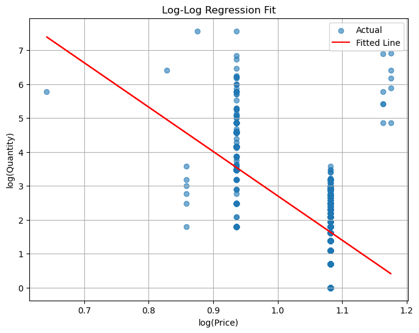

```python
purchases['log_quantity_pred'] = log_logsm.predict(sm.add_constant(purchases['log_price']))

# Plot actual vs predicted
plt.figure(figsize=(8, 6))
plt.scatter(purchases['log_price'], purchases['log_quantity'], label='Actual', alpha=0.6)
plt.plot(purchases['log_price'], purchases['log_quantity_pred'], color='red', label='Fitted Line')
plt.xlabel('log(Price)')
plt.ylabel('log(Quantity)')
plt.title('Log-Log Regression Fit')
plt.legend()
plt.grid(True)
plt.show()
```

```python
#Check SSE
log_log_sse = np.sum((purchases['log_quantity'] - purchases['log_quantity_pred'])**2)
print(f"SSE: {log_log_sse:.4f}")
```

```
SSE: 3282.0927
```